# HappyHotel

### Problem Setting

1. Design and excute a method to identify topics within reviews.
2. For each topic, find a robust means of assigning a score to each hotel in that topic.
3. For each of the ten hotels, what specific-to-that-hotel recommendations would you make to their general managers?

### EDA

```python
import pandas as pd
import numpy as np
import matplotlib.pyplot as plt
import seaborn as sn
import nltk
import gensim
from gensim.utils import simple_preprocess
from gensim.parsing.preprocessing import STOPWORDS
from nltk.stem import WordNetLemmatizer, SnowballStemmer
from nltk.stem.porter import *
import wordcloud
import pyLDAvis
import pyLDAvis.gensim

from gensim.models import LdaModel, LdaMulticore
from gensim.models import CoherenceModel
from gensim.models import HdpModel
#nltk.download('wordnet')
```

```python
data_happy = pd.read_csv("../data/hotel_happy_reviews.csv")
data_nhappy = pd.read_csv("../data/hotel_not_happy_reviews.csv")
```

```python
### concate happy and unhappy data
data = pd.concat([data_happy, data_nhappy])
data.reset_index(drop=True, inplace=True)
print("Number of happy reviews:", data_happy.shape[0])
print("Number of nhappy reviews:", data_nhappy.shape[0])
print("Number of total reviews:", data.shape[0])
```

```
Number of happy reviews: 26521
Number of nhappy reviews: 12411
Number of total reviews: 38932
```

#### Basic Analysis

##### Hotel Review Distributions

We first draw the distribution of reviews for different hotels.

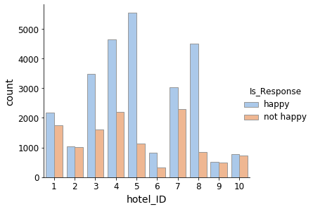

```python
ax = sn.catplot("hotel_ID", hue="Is_Response", kind="count", palette="pastel", edgecolor=".6", data=data)
plt.gcf().set_size_inches(6, 4)
plt.setp(ax._legend.get_texts(), fontsize='12')
plt.setp(ax._legend.get_title(), fontsize='12')
plt.xticks(size=12)
plt.yticks(size=12)
plt.xlabel("hotel_ID", fontsize=14)
plt.ylabel("count", fontsize=14)
plt.savefig("../data/figures/Hotel_review_dist.png", dpi=100);
```

For different hotels, the amount of reviews are differnt, also, the percentage of happy reviews and not happy reviews are different. Generally, the number of happy reviews are more than the number of unhappy reviews.

##### Review Words Distribution

Here, we checked whether the length of setence are different for reviews with different response.

```python
data["length_words"] = [len(i.split()) for i in list(data["Description"])]
```

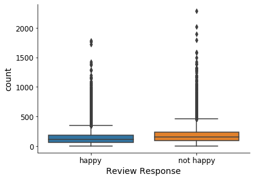

```python
ax = sn.catplot(x="Is_Response", y="length_words", data=data, kind="box")
plt.gcf().set_size_inches(6, 4)
plt.xticks(size=12)
plt.yticks(size=12)
plt.xlabel("Review Response", fontsize=14)
plt.ylabel("count", fontsize=14)
plt.savefig("../data/figures/Review_length.png", dpi=100);
```

Not happy reviews have more words compared with happy reviews, also both type of reviews have some outliers with many words.

```python
### One example for extremly long review
data[data["length_words"] == 2289]["Description"].values[0]
```

```
'OVERVIEW: We will never stay here again or recommend this hotel to anyone. Noisy bedrooms not only from the invasive sound of people stomping about in the room above and using their bathroom......but from the bedroom air conditioning which sounds, relentlessly, like being on a jet taking off! Booke…
```

#### Common Word in Reviews

To get the word vocabulary, we need to do some simple preprocessing:

```python
def preprocess(text):
    result = []
    for token in gensim.utils.simple_preprocess(text):
        if token not in gensim.parsing.preprocessing.STOPWORDS:
            result.append(WordNetLemmatizer().lemmatize(token, pos='v'))
    return result
```

```python
text = data["Description"][0:1].values[0]
print("Input review:", text)
print("Output words:", ",".join(preprocess(text)))
```

```
Input review: Stayed here with husband and sons on the way to an Alaska Cruise. We all loved the hotel, great experience. Ask for a room on the North tower, facing north west for the best views. We had a high floor, with a stunning view of the needle, the city, and even the cruise ships! We ordered …
Output words: stay,husband,sons,way,alaska,cruise,love,hotel,great,experience,ask,room,north,tower,face,north,west,best,view,high,floor,stun,view,needle,city,cruise,ship,order,room,service,dinner,enjoy,perfect,view,room,service,dinners,delicious,perfect,spot,walk,enjoy,city,forget,heavenly,bed,heave…
```

Based on this preprocessing, we can convert all reviews into word list. In next step, we create word_list, which includes all words for each review

```python
word_list = []
for idx, i in enumerate(list(data["Description"])):
    word_list.append(preprocess(i))
    if idx % 1000 == 0:
        print(idx)
```

[output not shown]

After get the word_list, we used gensim.corpora.Dictionary to build the dictionary for all words. This dictionary contains a lot of information of words:

1. looping the dictionary (iteritems(), token2id, id2token), we can get the tocken id and corresponding word
2. dictionary.cfs --> token_id, how many instances of this token are contained in the documents.
3. dictionary.dfs --> token_id, how many documents contain this token.
4. dictionary.num_docs --> number of documents processed
5. dictionary.num_pos --> number of processed words

```python
dictionary = gensim.corpora.Dictionary(word_list)
### fiter the words too uncommon and too common
print("Number of words:", len(dictionary))
dictionary.filter_extremes(no_below=15, no_above=0.50)
print("Number of words after filtering:", len(dictionary))
```

```
Number of words: 38779
Number of words after filtering: 6442
```

Based on current dictionary, we can get the count information for different type of reviews

```python
### Get the dictionary of word count for different type of reviews
happy_dict = {key:0 for key in dictionary.token2id.keys()}
no_happy_dict = {key:0 for key in dictionary.token2id.keys()}
for i in word_list[0:26521]:
    for ii in i:
        if ii in happy_dict:
            happy_dict[ii] += 1
for i in word_list[26521:]:
    for ii in i:
        if ii in no_happy_dict:
            no_happy_dict[ii] += 1
```

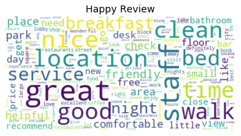

```python
wc = wordcloud.WordCloud(background_color="white", max_font_size=50, random_state=0).generate_from_frequencies(happy_dict)
plt.imshow(wc,interpolation="bilinear")
plt.title("Happy Review", size=14)
plt.axis("off");
#plt.savefig("../data/figures/Happy_Review_WordCloud.png", dpi=100);
```

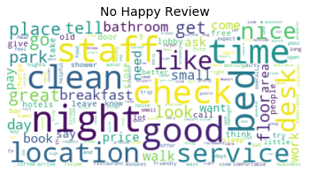

```python
wc = wordcloud.WordCloud(background_color="white", max_font_size=50, random_state=0).generate_from_frequencies(no_happy_dict)
plt.imshow(wc,interpolation="bilinear")
plt.title("No Happy Review", size=14)
plt.axis("off");
#plt.savefig("../data/figures/No_Happy_Review_WordCloud.png", dpi=100);
```

From wordcloud, it seems that some word are common in both type of reviews, but some are not. However, the trend is not clear.

### Topic Model Development

#### Get Bag of Words

We use dictionary.doc2bow to get the dictionary reporting **appear words** and **the number of times** in each review (document)

```python
bow_corpus = [dictionary.doc2bow(doc) for doc in word_list]
```

```python
### example
print("Fist review:", data["Description"].values[0])
for i in bow_corpus[0]:
    print(dictionary[i[0]], "appear", i[1], "times")
```

```
Fist review: Stayed here with husband and sons on the way to an Alaska Cruise. We all loved the hotel, great experience. Ask for a room on the North tower, facing north west for the best views. We had a high floor, with a stunning view of the needle, the city, and even the cruise ships! We ordered r…
alaska appear 1 times
ask appear 1 times
bed appear 1 times
best appear 1 times
city appear 2 times
cruise appear 2 times
delicious appear 1 times
dinner appear 1 times
dinners appear 1 times
enjoy appear 2 times
experience appear 1 times
face appear 1 times
floor appear 1 times
forget appear 1 times
great appear 1 times
heavenly appear 2 times
high appear 1 times
husband appear 1 times
love appear 1 times
needle appear 1 times
north appear 2 times
order appear 1 times
perfect appear 2 times
service appear 2 times
ship appear 1 times
sons appear 1 times
spot appear 1 times
stun appear 1 times
tower appear 1 times
view appear 3 times
walk appear 1 times
way appear 1 times
west appear 1 times
```

#### LDA

We are going to use LDA model to generate topics from our reviews. However, one challenge is that we need to determine the number of topics before we build the model. To solve this problem, we are doing Grid Search based on change of coherence.

##### Baseline

We randomly choose num_topics as 10 with chunksize as 1000, and train the corpos 10 times. Consider this as our baseline model

```python
lda = LdaMulticore(corpus=bow_corpus, id2word=dictionary, num_topics=10, random_state=100,
                chunksize=1000, passes=10, workers=4)
```

```python
lda.show_topics()
```

```
[(0,
  '0.021*"great" + 0.020*"nice" + 0.019*"walk" + 0.016*"clean" + 0.015*"pool" + 0.015*"staff" + 0.015*"area" + 0.014*"location" + 0.011*"downtown" + 0.011*"restaurants"'),
 (1,
  '0.051*"park" + 0.023*"night" + 0.018*"walk" + 0.018*"car" + 0.013*"street" + 0.013*"valet" + 0.011*"day" + 0.010*"lot" + 0.008*"block" + 0.008*"right"'),
 (2,
  '0.028*"bed" + 0.017*"bathroom" + 0.013*"small" + 0.013*"shower" + 0.012*"nice" + 0.011*"floor" + 0.010*"tv" + 0.008*"night" + 0.008*"like" + 0.007*"size"'),
 (3,
  '0.023*"time" + 0.021*"great" + 0.020*"location" + 0.019*"staff" + 0.015*"clean" + 0.014*"new" + 0.013*"square" + 0.012*"walk" + 0.012*"nyc" + 0.012*"york"'),
 (4,
  '0.027*"good" + 0.023*"free" + 0.019*"breakfast" + 0.015*"internet" + 0.013*"service" + 0.012*"nice" + 0.011*"price" + 0.010*"coffee" + 0.010*"location" + 0.009*"clean"'),
 (5,
  '0.019*"staff" + 0.015*"breakfast" + 0.015*"great" + 0.014*"service" + 0.010*"food" + 0.009*"friendly" + 0.008*"time" + 0.008*"bar" + 0.008*"restaurant" + 0.007*"enjoy"'),
 (6,
  '0.023*"san" + 0.016*"location" + 0.016*"francisco" + 0.016*"union" + 0.014*"walk" + 0.014*"square" + 0.011*"city" + 0.010*"great" + 0.010*"good" + 0.009*"cable"'),
 (7,
  '0.013*"like" + 0.013*"place" + 0.013*"look" + 0.011*"clean" + 0.010*"old" + 0.009*"night" + 0.008*"smell" + 0.008*"carpet" + 0.008*"good" + 0.007*"need"'),
 (8,
  '0.018*"check" + 0.014*"tell" + 0.014*"desk" + 0.011*"ask" + 0.011*"go" + 0.010*"time" + 0.010*"say" + 0.010*"call" + 0.009*"night" + 0.009*"get"'),
 (9,
  '0.025*"great" + 0.023*"service" + 0.020*"staff" + 0.016*"view" + 0.013*"chicago" + 0.012*"location" + 0.009*"boston" + 0.009*"beautiful" + 0.008*"experience" + 0.008*"wonderful"')]
```

```python
coherence_model_lda = CoherenceModel(model=lda, texts=word_list, dictionary=dictionary, coherence="c_v")
```

```python
coherence_lda = coherence_model_lda.get_coherence()
```

```python
print("Coherence of our baseline model", coherence_lda)
```

```
Coherence of our baseline model 0.43231920185039313
```

##### Grid Search

Since we need to determine the number of topics in LDA model, grid search has been conducted, and coherence for different number of topics have been recorded.

```python
def compute_coherence_values(corpus, dictionary, texts, k):
    lda_model = LdaMulticore(corpus=corpus, id2word=dictionary, num_topics=k, random_state=0, chunksize=1000, passes=10, per_word_topics=True, workers=4)

    coherence_model_lda = CoherenceModel(model=lda_model, texts=texts, dictionary=dictionary, coherence='c_v')

    return coherence_model_lda.get_coherence()
```

```python
# Topic range
min_topics = 2
max_topics = 15
step_size = 1
topics_range = range(min_topics, max_topics, step_size)
# Validation sets
num_of_docs = len(bow_corpus)
corpus_sets = [gensim.utils.ClippedCorpus(bow_corpus, int(num_of_docs*0.80)),
               bow_corpus]
corpus_title = ['80% Corpus', '100% Corpus']
model_results = {'Validation_Set': [],
                 'Topics': [],
                 'Coherence': []
                }
# iterate through validation corpuses
for i in range(1, len(corpus_sets)):
    # iterate through number of topics
    for k in topics_range:
        cv = compute_coherence_values(corpus=corpus_sets[i], dictionary=dictionary, texts=word_list, k=k)
        # Save the model results
        model_results['Validation_Set'].append(corpus_title[i])
        model_results['Topics'].append(k)
        model_results['Coherence'].append(cv)
#pd.DataFrame(model_results).to_csv('lda_tuning_results.csv', index=False)
```

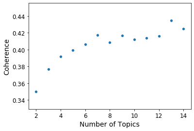

```python
ax = sn.scatterplot(model_results["Topics"], model_results["Coherence"])
plt.xticks(size=12)
plt.yticks(size=12)
plt.xlabel("Number of Topics", fontsize=14)
plt.ylabel("Coherence", fontsize=14)
plt.savefig("../data/figures/LDA_GridSearch.png", dpi=100);
```

Thus, best coherence has been achieved by number of topics = 13.

##### Best Model

```python
lda_best = LdaMulticore(corpus=bow_corpus, id2word=dictionary, num_topics=13, random_state=0, chunksize=1000, passes=20, workers=4)
```

```python
lda_best.show_topics()
```

```
[(9,
  '0.079*"park" + 0.022*"car" + 0.022*"night" + 0.020*"valet" + 0.015*"pay" + 0.013*"nice" + 0.012*"day" + 0.011*"get" + 0.010*"view" + 0.010*"rate"'),
 (6,
  '0.019*"like" + 0.016*"look" + 0.015*"place" + 0.015*"old" + 0.013*"smell" + 0.012*"carpet" + 0.011*"dirty" + 0.008*"smoke" + 0.008*"need" + 0.008*"clean"'),
 (8,
  '0.044*"walk" + 0.019*"location" + 0.017*"great" + 0.016*"block" + 0.015*"restaurants" + 0.014*"staff" + 0.014*"distance" + 0.012*"clean" + 0.012*"shop" + 0.011*"close"'),
 (3,
  '0.022*"good" + 0.017*"night" + 0.015*"location" + 0.014*"noise" + 0.014*"clean" + 0.013*"bed" + 0.012*"small" + 0.012*"price" + 0.011*"staff" + 0.010*"review"'),
 (10,
  '0.030*"time" + 0.023*"new" + 0.022*"great" + 0.021*"location" + 0.020*"square" + 0.018*"york" + 0.018*"nyc" + 0.017*"th" + 0.014*"staff" + 0.014*"walk"'),
 (12,
  '0.022*"check" + 0.017*"tell" + 0.016*"desk" + 0.013*"ask" + 0.013*"go" + 0.012*"call" + 0.011*"say" + 0.011*"get" + 0.011*"time" + 0.011*"night"'),
 (1,
  '0.024*"walk" + 0.022*"san" + 0.020*"location" + 0.018*"great" + 0.017*"union" + 0.016*"francisco" + 0.015*"square" + 0.013*"seattle" + 0.013*"street" + 0.012*"city"'),
 (2,
  '0.025*"airport" + 0.022*"inn" + 0.020*"shuttle" + 0.020*"clean" + 0.016*"breakfast" + 0.013*"staff" + 0.012*"good" + 0.012*"san" + 0.011*"great" + 0.010*"area"'),
 (11,
  '0.028*"bed" + 0.022*"bathroom" + 0.019*"shower" + 0.016*"floor" + 0.014*"tv" + 0.012*"small" + 0.009*"nice" + 0.009*"water" + 0.009*"light" + 0.008*"desk"'),
 (5,
  '0.060*"breakfast" + 0.026*"coffee" + 0.018*"free" + 0.014*"good" + 0.011*"nice" + 0.011*"morning" + 0.011*"include" + 0.010*"food" + 0.010*"clean" + 0.010*"hot"')]
```

```python
coherence_model_lda_best = CoherenceModel(model=lda_best, texts=word_list, dictionary=dictionary, coherence="c_v")
coherence_lda_best = coherence_model_lda_best.get_coherence()
```

```python
print("Coherence of our best model", coherence_lda_best)
```

```
Coherence of our best model 0.450461816385976
```

##### Visualize Topics

```python
pyLDAvis.enable_notebook()
LDAvis_prepared = pyLDAvis.gensim.prepare(lda_best, bow_corpus, dictionary)
```

```python
LDAvis_prepared
```

[interactive chart not shown]

It should be noted that the order of topics shown here is not same as the order provided from original lda_best.

```python
LDAvis_prepared.topic_order
```

```
[13, 4, 5, 12, 1, 11, 8, 7, 9, 6, 3, 10, 2]
```

### Hotel Score based on Topic

#### Get Review Topic

##### Example for first review

```python
review_topic = lda_best.get_document_topics(bow_corpus, minimum_probability=0.1)
```

```python
for i in review_topic[0]:
    print("Topic", LDAvis_prepared.topic_order.index(int(i[0]) + 1) + 1, i[1])
```

```
Topic 5 0.58272696
Topic 13 0.26347616
Topic 3 0.13590209
```

Each review can have multiple topics, here, we only consider topics with probablity larger than 0.1

##### Determine score for hotel based on topic

To determine the score of hotel on each topic, we just use a very naive way: count the number of that topic appearing in reviews and divide it by the total number of reviews. Here, we use total reviews, only happy reviews, and only not happy review to get the score for hotel.

```python
def get_score(index, review_topic):
    total_review = len(index)
    topic_total = [review_topic[i] for i in index]
    topic_dict = {key: 0 for key in range(13)}
    for key in range(13):
        for review_topic in topic_total:
            for topic in review_topic:
                if topic[0] == key:
                    topic_dict[key] += 1
    score_dict = {key: topic_dict[key]/total_review for key in range(13)}
    return score_dict
```

```python
score_dic = {}
for i in range(1,11):
    index = list(data[(data["hotel_ID"] == i)].index)
    score = get_score(index, review_topic)
    happy_index = list(data[(data["hotel_ID"] == i)&(data["Is_Response"] == "happy")].index)
    happy_score = get_score(happy_index, review_topic)
    nohappy_index = list(data[(data["hotel_ID"] == i)&(data["Is_Response"] == "not happy")].index)
    nohappy_score = get_score(nohappy_index, review_topic)
    score_dic[i] = [score, happy_score, nohappy_score]
```

```python
score_dic[5]
```

```
[{0: 0.3621670158635139,
  1: 0.14112541155342712,
  2: 0.21131397785094283,
  3: 0.3132295719844358,
  4: 0.3510924872792577,
  5: 0.21266087997605507,
  6: 0.15234959592936248,
  7: 0.2699790481891649,
  8: 0.24139479197844957,
  9: 0.17150553726429213,
  10: 0.25890451960490873,
  11: 0.2517210416043101,
  12: 0.26967973660580663},
 {0: 0.4007220216606498,
  1: 0.151985559566787,
```

[output cut: 24 more lines]

#### Visualization

##### Hotel Level

```python
Hotel_5_total = pd.DataFrame({"topic_initial":list(score_dic[5][0]), "score": list(score_dic[5][0].values()), "type": "total"})
Hotel_5_happy = pd.DataFrame({"topic_initial":list(score_dic[5][1]), "score": list(score_dic[5][1].values()), "type": "happy"})
Hotel_5_nohappy = pd.DataFrame({"topic_initial":list(score_dic[5][2]), "score": list(score_dic[5][2].values()), "type": "not happy"})
```

```python
Hotel_5 = pd.concat([Hotel_5_total, Hotel_5_happy, Hotel_5_nohappy])
Hotel_5["topic"] = [LDAvis_prepared.topic_order.index(i+1) + 1 for i in list(Hotel_5["topic_initial"])]
```

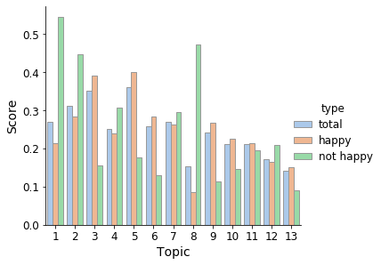

```python
ax = sn.catplot(x="topic", y="score", hue="type", kind="bar", palette="pastel", edgecolor=".6", data=Hotel_5)
plt.gcf().set_size_inches(6, 4)
plt.setp(ax._legend.get_texts(), fontsize='12')
plt.setp(ax._legend.get_title(), fontsize='12')
plt.xticks(size=12)
plt.yticks(size=12)
plt.xlabel("Topic", fontsize=14)
plt.ylabel("Score", fontsize=14)
#plt.tight_layout(pad=1)
plt.savefig("../data/figures/Hotel5_score.png", dpi=100);
```

##### Topic Level

```python
index = np.argsort([score_dic[i][0][0] for i in range(1,11)])
Topic5 = sorted([score_dic[i][0][0] for i in range(1,11)], reverse=True)
```

[figure not shown]

```python
fig = plt.figure(figsize=[4,6])
pal = sn.light_palette("green", n_colors=10, reverse=True)
sn.barplot(x=Topic5,y=[str("Hotel" + str(i)) for i in range(1,11)], palette=np.array(pal))
plt.yticks([i for i in range(10)], ["Hotel_" + str(i+1) for i in index], size=12)
plt.xticks(size=12)
plt.ylim([10,-0.5])
plt.xlim(xmin=0.20)
plt.xlabel("Topic5 Score", fontsize=14)
plt.tight_layout()
plt.savefig("../data/figures/Topic5.png", dpi=100);
```

### Future Work

Validation of LDA topics: classify the happy and unhappy reviews.